```
============================================
; Title:       BU 320 Week 11 — Bayes' Theorem and Shannon Entropy
; Author:      Hali Sarah Parsons
; Date:        24 May 2026
; Description: Three problems covering Bayes' Theorem applied to a
;              manufacturing probability tree, a custom Shannon entropy
;              function built from the Hadrien (2021) formula on p. 143,
;              and a comparison of entropy across two discrete distributions.
============================================
```

# BU 320 Week 11 — Bayes' Theorem and Shannon Entropy

**Hali Sarah Parsons | Bellevue University | May 2026**

## Overview

This notebook covers three problems from the Week 11 assignment:

1. **Bayes' Theorem** — two conditional probability calculations from a manufacturing probability tree
2. **Entropy Function** — a custom Python function implementing the Shannon entropy formula from Hadrien (2021, p. 143)
3. **Comparing Entropies** — applying that function to two distributions and interpreting the difference

All three connect to the same underlying idea: how much uncertainty exists in a probability distribution, and how Bayes' Theorem updates that uncertainty when new evidence arrives.

```python
import numpy as np
import matplotlib.pyplot as plt
import matplotlib.patches as mpatches

print("Imports loaded.")
```

```
Imports loaded.
```

## Problem 1: Bayes' Theorem — Manufacturing Defects

### Setup

A graphics card is manufactured by three processes with the following prior probabilities and defect rates from the tree diagram:

| Process | Prior P(Process) | P(Def \| Process) | P(Not Def \| Process) |
| --- | --- | --- | --- |
| A | 0.5 | 0.03 | 0.97 |
| B | 0.3 | 0.02 | 0.98 |
| C | 0.2 | 0.04 | 0.96 |

### Bayes' Theorem

Bayes' Theorem updates a prior probability using observed evidence:

[P(Process | Evidence) = (P(Process) × P(Evidence | Process)) / P(Evidence)]

The denominator [P(Evidence)] is the **total probability** of observing that evidence across all possible processes — calculated by summing each process's contribution:

[P(Evidence) = P(A) × P(Evidence|A) + P(B) × P(Evidence|B) + P(C) × P(Evidence|C)]

This is the **law of total probability**. It ensures the denominator accounts for every path through the tree that could have produced the observed outcome.

```python
# ── Prior probabilities (from tree diagram) ──────────────────────────────
P_A = 0.5
P_B = 0.3
P_C = 0.2

# ── Conditional probabilities (from tree diagram) ────────────────────────
P_Def_given_A    = 0.03;  P_NotDef_given_A = 0.97
P_Def_given_B    = 0.02;  P_NotDef_given_B = 0.98
P_Def_given_C    = 0.04;  P_NotDef_given_C = 0.96

# ── Joint probabilities: each branch of the tree ─────────────────────────
# Multiply along each branch: P(Process) × P(Outcome | Process)
P_A_and_Def    = P_A * P_Def_given_A
P_B_and_Def    = P_B * P_Def_given_B
P_C_and_Def    = P_C * P_Def_given_C

P_A_and_NotDef = P_A * P_NotDef_given_A
P_B_and_NotDef = P_B * P_NotDef_given_B
P_C_and_NotDef = P_C * P_NotDef_given_C

print("Joint probabilities (branch × leaf):")
print(f"  P(A ∩ Def)     = {P_A:.1f} × {P_Def_given_A:.2f} = {P_A_and_Def:.4f}")
print(f"  P(B ∩ Def)     = {P_B:.1f} × {P_Def_given_B:.2f} = {P_B_and_Def:.4f}")
print(f"  P(C ∩ Def)     = {P_C:.1f} × {P_Def_given_C:.2f} = {P_C_and_Def:.4f}")
print(f"  P(A ∩ Not Def) = {P_A:.1f} × {P_NotDef_given_A:.2f} = {P_A_and_NotDef:.4f}")
print(f"  P(B ∩ Not Def) = {P_B:.1f} × {P_NotDef_given_B:.2f} = {P_B_and_NotDef:.4f}")
print(f"  P(C ∩ Not Def) = {P_C:.1f} × {P_NotDef_given_C:.2f} = {P_C_and_NotDef:.4f}")
```

```
Joint probabilities (branch × leaf):
  P(A ∩ Def)     = 0.5 × 0.03 = 0.0150
  P(B ∩ Def)     = 0.3 × 0.02 = 0.0060
  P(C ∩ Def)     = 0.2 × 0.04 = 0.0080
  P(A ∩ Not Def) = 0.5 × 0.97 = 0.4850
  P(B ∩ Not Def) = 0.3 × 0.98 = 0.2940
  P(C ∩ Not Def) = 0.2 × 0.96 = 0.1920
```

```python
# ── Total probability of Defective and Not Defective ─────────────────────
# Sum down the defective column — the law of total probability
P_Def    = P_A_and_Def + P_B_and_Def + P_C_and_Def
P_NotDef = P_A_and_NotDef + P_B_and_NotDef + P_C_and_NotDef

print(f"Total P(Defective)     = {P_A_and_Def:.4f} + {P_B_and_Def:.4f} + {P_C_and_Def:.4f} = {P_Def:.4f}")
print(f"Total P(Not Defective) = {P_A_and_NotDef:.4f} + {P_B_and_NotDef:.4f} + {P_C_and_NotDef:.4f} = {P_NotDef:.4f}")
print(f"\nVerification (should sum to 1.0): {P_Def + P_NotDef:.4f}")
```

```
Total P(Defective)     = 0.0150 + 0.0060 + 0.0080 = 0.0290
Total P(Not Defective) = 0.4850 + 0.2940 + 0.1920 = 0.9710

Verification (should sum to 1.0): 1.0000
```

### Part (a): P(A | Defective)

A randomly chosen card is defective. What is the probability it came from Process A?

Applying Bayes' Theorem:

[P(A | Def) = P(A ∩ Def) / P(Def) = (P(A) × P(Def|A)) / P(Def)]

```python
# Part (a): P(A | Defective)
P_A_given_Def = P_A_and_Def / P_Def

print("Part (a): P(A | Defective)")
print(f"  Numerator:   P(A) × P(Def|A) = {P_A} × {P_Def_given_A} = {P_A_and_Def:.4f}")
print(f"  Denominator: P(Def)           = {P_Def:.4f}")
print(f"  P(A | Def)  = {P_A_and_Def:.4f} / {P_Def:.4f} = {P_A_given_Def:.6f}")
print(f"\n  Answer: P(A | Defective) ≈ {P_A_given_Def:.4f}  ({P_A_given_Def*100:.2f}%)")
```

```
Part (a): P(A | Defective)
  Numerator:   P(A) × P(Def|A) = 0.5 × 0.03 = 0.0150
  Denominator: P(Def)           = 0.0290
  P(A | Def)  = 0.0150 / 0.0290 = 0.517241

  Answer: P(A | Defective) ≈ 0.5172  (51.72%)
```

### Part (b): P(C | Not Defective)

A randomly chosen card is not defective. What is the probability it came from Process C?

[P(C | Not Def) = P(C ∩ Not Def) / P(Not Def) = (P(C) × P(Not Def|C)) / P(Not Def)]

```python
# Part (b): P(C | Not Defective)
P_C_given_NotDef = P_C_and_NotDef / P_NotDef

print("Part (b): P(C | Not Defective)")
print(f"  Numerator:   P(C) × P(Not Def|C) = {P_C} × {P_NotDef_given_C} = {P_C_and_NotDef:.4f}")
print(f"  Denominator: P(Not Def)            = {P_NotDef:.4f}")
print(f"  P(C | Not Def) = {P_C_and_NotDef:.4f} / {P_NotDef:.4f} = {P_C_given_NotDef:.6f}")
print(f"\n  Answer: P(C | Not Defective) ≈ {P_C_given_NotDef:.4f}  ({P_C_given_NotDef*100:.2f}%)")
```

```
Part (b): P(C | Not Defective)
  Numerator:   P(C) × P(Not Def|C) = 0.2 × 0.96 = 0.1920
  Denominator: P(Not Def)            = 0.9710
  P(C | Not Def) = 0.1920 / 0.9710 = 0.197734

  Answer: P(C | Not Defective) ≈ 0.1977  (19.77%)
```

**Interpretation:** Process C has a prior probability of 20% and a 96% non-defect rate. Given that a card is not defective, the posterior probability it came from Process C is about **19.77%** — very close to, but slightly below, its prior. That small drop happens because Processes A and B have slightly higher non-defect rates (97% and 98%), so knowing a card is good tilts the probability very slightly toward them. The effect is subtle because the non-defect rates across all three processes are close together.

```python
# Summary table — posterior probabilities for both parts
print("Full Posterior Summary")
print("=" * 55)
print(f"{'Process':<10} {'P(Process|Def)':>16} {'P(Process|Not Def)':>20}")
print("-" * 55)
for process, prior, p_def_giv, p_nd_giv in [
    ('A', P_A, P_Def_given_A, P_NotDef_given_A),
    ('B', P_B, P_Def_given_B, P_NotDef_given_B),
    ('C', P_C, P_Def_given_C, P_NotDef_given_C),
]:
    post_def    = (prior * p_def_giv) / P_Def
    post_notdef = (prior * p_nd_giv)  / P_NotDef
    print(f"{process:<10} {post_def:>16.6f} {post_notdef:>20.6f}")
print("=" * 55)
```

```
Full Posterior Summary
=======================================================
Process      P(Process|Def)   P(Process|Not Def)
-------------------------------------------------------
A                  0.517241             0.499485
B                  0.206897             0.302781
C                  0.275862             0.197734
=======================================================
```

## Problem 2: Shannon Entropy Function

**Shannon entropy** measures the uncertainty in a probability distribution. A distribution where all outcomes are equally probable has maximum entropy — there is no way to predict which outcome will occur. A distribution where one outcome dominates has low entropy — the outcome is mostly predictable.

The formula from Hadrien (2021, p. 143):

[H(X) = -Σ pᵢ × log₂(pᵢ)]

Where [pᵢ] is the probability of outcome [i], and the sum runs over all outcomes. The negative sign flips the result positive — since [log₂(pᵢ)] is always negative or zero for valid probabilities (0 < p ≤ 1), the negative makes [H(X)] always non-negative.

Units are **bits** — entropy measured in base-2 logarithms.

Two edge cases to handle:

- [pᵢ = 0]: [0 × log₂(0)] is defined as 0 by convention (a zero-probability outcome contributes nothing to uncertainty).
- [pᵢ = 1]: [1 × log₂(1) = 0], so a certain outcome yields [H = 0] — no uncertainty.

```python
def entropy(probs):
    """
    Calculates Shannon entropy of a discrete probability distribution.

    Formula (Hadrien, 2021, p. 143):
        H(X) = -sum(p_i * log2(p_i)) for all i

    Parameters
    ----------
    probs : array-like
        Probability values p1, p2, ..., pn for a discrete distribution.
        Values must be non-negative and should sum to 1.

    Returns
    -------
    float
        Shannon entropy in bits (base-2 logarithm).
    """
    probs = np.array(probs, dtype=float)

    # Filter out zero probabilities — log2(0) is undefined, but
    # the convention 0 * log2(0) = 0 means they contribute nothing
    probs = probs[probs > 0]

    return -np.sum(probs * np.log2(probs))

# ── Sanity checks ────────────────────────────────────────────────────────
# A fair coin: two equally probable outcomes → maximum entropy for 2 outcomes = 1 bit
H_fair_coin = entropy([0.5, 0.5])
print(f"Fair coin H([0.5, 0.5]) = {H_fair_coin:.4f} bits  (expected: 1.0000)")

# A certain outcome: all probability on one value → no uncertainty → H = 0
H_certain = entropy([1.0, 0.0])
print(f"Certain   H([1.0, 0.0]) = {H_certain:.4f} bits  (expected: 0.0000)")

# Uniform over 4 outcomes → H = log2(4) = 2 bits
H_uniform4 = entropy([0.25, 0.25, 0.25, 0.25])
print(f"Uniform-4 H([0.25×4])   = {H_uniform4:.4f} bits  (expected: 2.0000)")
```

```
Fair coin H([0.5, 0.5]) = 1.0000 bits  (expected: 1.0000)
Certain   H([1.0, 0.0]) = -0.0000 bits  (expected: 0.0000)
Uniform-4 H([0.25×4])   = 2.0000 bits  (expected: 2.0000)
```

## Problem 3: Comparing Entropies of X and Y

Two random variables each take values 1 through 5:

| Value | P(X = x) | P(Y = y) |
| --- | --- | --- |
| 1 | 0.2 | 0.1 |
| 2 | 0.2 | 0.4 |
| 3 | 0.2 | 0.1 |
| 4 | 0.2 | 0.3 |
| 5 | 0.2 | 0.1 |

X is **uniform** — every outcome is equally probable. Y is **concentrated** — outcomes 2 and 4 together carry 70% of the probability.

### Part (a): Calculate H(X) and H(Y)

```python
# Define distributions
p_X = [0.2, 0.2, 0.2, 0.2, 0.2]   # uniform over 5 outcomes
p_Y = [0.1, 0.4, 0.1, 0.3, 0.1]   # concentrated — Y=2 and Y=4 dominate

H_X = entropy(p_X)
H_Y = entropy(p_Y)

print(f"H(X) = {H_X:.6f} bits")
print(f"H(Y) = {H_Y:.6f} bits")
print(f"\nH(X) > H(Y): {H_X > H_Y}")
print(f"Difference: H(X) - H(Y) = {H_X - H_Y:.6f} bits")

# Verify H(X) = log2(5) for a uniform distribution over 5 outcomes
print(f"\nVerification: log2(5) = {np.log2(5):.6f}  (should match H(X))")
```

```
H(X) = 2.321928 bits
H(Y) = 2.046439 bits

H(X) > H(Y): True
Difference: H(X) - H(Y) = 0.275489 bits

Verification: log2(5) = 2.321928  (should match H(X))
```

### Part (b): Compare H(X) and H(Y) — Intuitive Explanation

**H(X) = 2.3219 bits > H(Y) = 2.0464 bits**

X has higher entropy. The intuition follows directly from what entropy measures — uncertainty before observing an outcome.

For X, every outcome is equally likely at 20%. There is no way to make a better-than-random guess at what value X will take. Each outcome carries the same amount of surprise. That equal spread produces the maximum possible entropy for a five-outcome distribution — [H(X) = log₂(5) ≈ 2.3219] bits.

For Y, outcomes 2 and 4 together account for 70% of the probability. Before observing Y, a reasonable guess is already "probably 2 or 4." The distribution is already telling us something — and that advance information reduces entropy. Outcomes 1, 3, and 5 each carry only 10%, so they add less uncertainty to the mix. The result is lower entropy even though Y has the same five possible values as X.

The study guide framing from JDataLab (2017) helps here: entropy measures the average number of yes/no questions needed to identify the outcome. For X, every question eliminates exactly one outcome — five equally weighted options require the most questions on average. For Y, the first question "Is it 2 or 4?" eliminates 70% of the probability mass in one step — fewer questions needed on average, lower entropy.

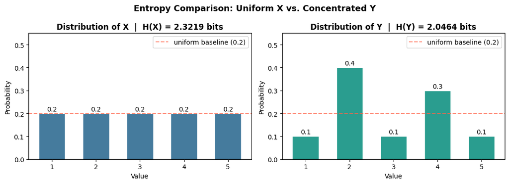

```
H(X) = 2.321928 bits — maximum entropy for 5 outcomes (uniform)
H(Y) = 2.046439 bits — lower entropy due to concentration at Y=2 and Y=4
H(X) is 0.275489 bits higher than H(Y)
```

```python
# Visualize the two distributions and their entropies side by side
fig, axes = plt.subplots(1, 2, figsize=(11, 4))
values = [1, 2, 3, 4, 5]

# X — uniform
axes[0].bar(values, p_X, color='#457B9D', edgecolor='white', width=0.6)
axes[0].axhline(y=0.2, color='tomato', linestyle='--', alpha=0.7, label='uniform baseline (0.2)')
axes[0].set_title(f'Distribution of X  |  H(X) = {H_X:.4f} bits', fontweight='bold')
axes[0].set_xlabel('Value')
axes[0].set_ylabel('Probability')
axes[0].set_ylim(0, 0.55)
axes[0].set_xticks(values)
axes[0].legend()
for v, p in zip(values, p_X):
    axes[0].text(v, p + 0.01, f'{p}', ha='center', fontsize=10)

# Y — concentrated
axes[1].bar(values, p_Y, color='#2A9D8F', edgecolor='white', width=0.6)
axes[1].axhline(y=0.2, color='tomato', linestyle='--', alpha=0.7, label='uniform baseline (0.2)')
axes[1].set_title(f'Distribution of Y  |  H(Y) = {H_Y:.4f} bits', fontweight='bold')
axes[1].set_xlabel('Value')
axes[1].set_ylabel('Probability')
axes[1].set_ylim(0, 0.55)
axes[1].set_xticks(values)
axes[1].legend()
for v, p in zip(values, p_Y):
    axes[1].text(v, p + 0.01, f'{p}', ha='center', fontsize=10)

plt.suptitle('Entropy Comparison: Uniform X vs. Concentrated Y', fontsize=13, fontweight='bold')
plt.tight_layout()
plt.show()

print(f"H(X) = {H_X:.6f} bits — maximum entropy for 5 outcomes (uniform)")
print(f"H(Y) = {H_Y:.6f} bits — lower entropy due to concentration at Y=2 and Y=4")
print(f"H(X) is {H_X - H_Y:.6f} bits higher than H(Y)")
```

## Summary

| Problem | Result |
| --- | --- |
| P(A \| Defective) | **0.5172** (~51.72%) |
| P(C \| Not Defective) | **0.1977** (~19.77%) |
| H(X) — uniform distribution | **2.3219 bits** |
| H(Y) — concentrated distribution | **2.0464 bits** |
| Which is larger? | **H(X) > H(Y)** — uniform distributions always carry maximum entropy |

All three problems connect through the idea of information and uncertainty. Bayes' Theorem updates probability estimates when evidence arrives — which is precisely what reduces entropy in a decision tree: each split selects the feature that most reduces uncertainty (maximizes information gain). Shannon entropy quantifies exactly how much uncertainty exists before that update happens.

## References

Hadrien, J. (2021). *Essential math for data science.* O'Reilly Media.

JDataLab. (2017, February 22). Measuring uncertainty by calculating Shannon entropy. https://www.jdatalab.com/data_science_and_data_mining/2017/02/22/shannon-entropy.html